# Family Feud - NYT Crossword Edition

tidytuesday

code

Author

Simon Heitin

Published

September 28, 2022

If there’s one thing that unites my family, it’s a love of food[^1]. If there are two things that unite my family, they are a love of food and a love of puzzles. So, when I saw that tidytuesday had wrangled [a set of crossword clues and answers](https://github.com/rfordatascience/tidytuesday/blob/master/data/2022/2022-04-19/readme.md), I knew what I had to do.

I emailed my family members and asked them to submit one guess as to what they thought was the most common 4-letter crossword answer.

```r
library(tidyverse)
library(lubridate)

path <-
  'https://raw.githubusercontent.com/rfordatascience/tidytuesday/master/data/2022/2022-04-19/times.csv'

times <- read_csv(path)

times_clean <- times %>%
  mutate(answer = str_remove_all(answer, " "),
         answer_len = nchar(answer)) %>%
  filter(!is.na(puzzle_date))

#these are the guesses. I provided a pseudonym for each family member to keep
# things friendly. https://babynames.com/names/random-name-generator.php was a
#  big help
fam_responses_anon <- data.frame(
  stringsAsFactors = FALSE,
               answer = c("ANTE","ERRS","HOME",
                          "IDEA","DERN","BEAU","SETS","EONS","ERAS","TIME",
                          "WELL","WHAT","ACRE","STAG","ARIL", "LAST", "CLAM",
                          "FOUR", "WILL", "BALL"),
            pseudonym = c("Keona","Gordian","Zai",
                          "Makaila","Olof","Quintana","Selene","Ceron",
                          "Harrison","Mignonette","Tua","Alysha","Ziva",
                          "Maddox","Mervin", "Ultimate Warrior", "Janet",
                          "Tarzan", "Spock", "Sally")
   )

# get the number of occurrences for each 4-letter word
answers_ordered <- times_clean %>%
  filter(answer_len == 4) %>%
  count(answer, name = "n_appearances") %>%
  arrange(desc(n_appearances))

# to calculate percentiles, we need to
answers_pctile <- answers_ordered %>%
  count(n_appearances, name = "n_answers") %>%
  arrange(desc(n_appearances)) %>%
  mutate(num_better_answers = lag(cumsum(n_answers), default = 0),
         pct_better_answers = num_better_answers / sum(n_answers),
         pctile = 1-pct_better_answers) %>%
  right_join(answers_ordered, by = "n_appearances")

# now just get the answers from my family
family_answers_pctile <- answers_pctile %>%
  right_join(fam_responses_anon, by = "answer") %>%
  mutate(pctile = replace_na(pctile, 0),
         num_better_answers = replace_na(num_better_answers, 2000))
```

## Bum Bum Ba Da Buuuuum - Results

The plot below shows the results of our challenge. The y-axis is the percentile for how common each 4-letter word is. So, if a word is in the 90th percentile, then it is more common than 90% of all 4-letter words (that appeared in at least one crossword puzzle).

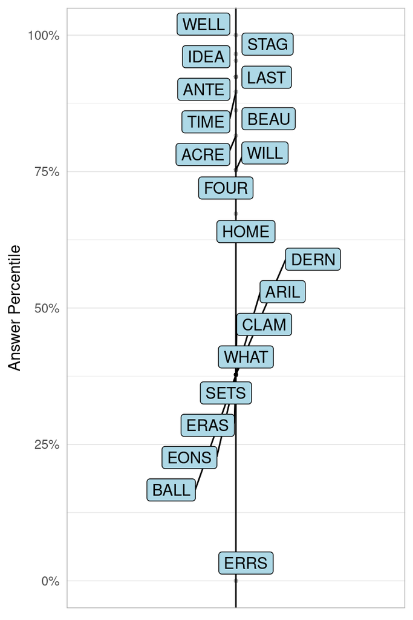

Family Guesses and Their Resulting Percentiles

```r
library(ggrepel)
library(scales)

 family_answers_pctile %>%
  ggplot(aes(y = pctile)) +
  geom_vline(xintercept = 0) +
  geom_point(aes(x = 0), alpha = .3, stroke = 0) +
  # stat_ecdf() +
  geom_label_repel(aes(label = answer, x = 0), max.overlaps = 20, fill = "light blue") +
  scale_y_continuous(labels = label_percent(), limits = c(0,1)) +
  theme_light() +
  theme(axis.text.x=element_blank(),
        axis.ticks=element_blank(),
        axis.title.x=element_blank(),
        panel.grid.major.x = element_blank(),
        panel.grid.minor.x = element_blank())  +
  labs(y = "Answer Percentile")
```

A keen eye will note that the top answer, “WELL”, is at the 100th Percentile. That’s right, one family member chose the absolute most common 4-letter crossword clue! It’s no wonder that this is also the person who made a living out of playing poker through serious study and computer simulation.

## Try For Yourself

Type an answer in ALL CAPS in the text box in the first column below. This is limited to 4-letter answers. The time range is 2012-12-27 to 2021-09-12, though the data appears to be most complete between 2017 and 2021.

```r
library(reactable)
answers_pctile %>%
  mutate(percentile = scales::percent(pctile, accuracy = .01)) %>%
  select(`Answer` = answer,
         `Answer Percentile` = percentile,
         `No. of Puzzles in Which Answer Appeared` = n_appearances) %>%
  reactable::reactable(filterable = TRUE, defaultPageSize = 1)
```

| Answer | Answer Percentile | No. of Puzzles in Which Answer Appeared |
| --- | --- | --- |
| WELL | 100.00% | 30 |
| FAIR | 99.96% | 27 |
| STAR | 99.93% | 25 |
| DOWN | 99.89% | 23 |
| ANTI | 99.85% | 22 |
| ECHO | 99.85% | 22 |
| SPOT | 99.85% | 22 |
| ACHE | 99.74% | 20 |
| ITEM | 99.74% | 20 |
| DASH | 99.66% | 19 |

[output cut: 2661 more lines]

## Footnotes

[^1]: this post is not about about food but maybe the next one should be